# Objective of the project

The train data (train_v2.csv) contains user transactions from August 1st 2016 to April 30th 2018. The test data (test_v2.csv) contains user transactions from May 1st 2018 to October 15th 2018.

Our goal is to predict users' trasactions during the period 2018.12 - 2019.1 given the test data(test_v2.csv).

To see the more detailed data descriptions and evaluation creterion etc, please visit the site, https://www.kaggle.com/c/ga-customer-revenue-prediction

# Stretegy

Our strategy is to set the data from May 1st 2017 to October 31st 2017 as the training set and extract target variable from the data of period, December 1st 2017 to January 31st 2018.

A few important steps are the followings:

1. We first explore how the given data set looks like. We will see most columns are categorical columns in which some of the have thousands of unique values. Also, in this stage, we simply clean data for furture use. For instance, we drop columns with constant values which are not useful for our training stage.

2. Since many categorical columns have numerous unique values, we can not simply apply one-hot encoding for those columns. Thus, we will perform Principal Component Analysis (PCA) in the later stage. To do so, we investigate how each categorical columns are related to the amount of transactions so that we determine the dimension in the PCA part.

3. Based on the observations in the previous stage, we perform feature engineering such as PCA, one-hot encoding, normalization etc.

4. While we are asked to predict each visitor's future trasaction amount, the given data set consists of individual visit log information.Therefore, we rearrange data with respect to visitor IDs.

5. Finally, we perform training using Long-Short Term Memory(LSTM) with each visitors' visit history.

```python
# This Python 3 environment comes with many helpful analytics libraries installed
# It is defined by the kaggle/python Docker image: https://github.com/kaggle/docker-python
# For example, here's several helpful packages to load

import numpy as np # linear algebra
import pandas as pd # data processing, CSV file I/O (e.g. pd.read_csv)
import os
import json
import time
from datetime import datetime
from pandas import json_normalize
#from pandas.io.json import json_normalize
from sklearn.metrics import mean_squared_error
from sklearn.model_selection import KFold
import matplotlib.pyplot as plt
import seaborn as sns
import gc
from zipfile import ZipFile
gc.enable()

import plotly.io as pio
pio.renderers.default = "svg"
# Input data files are available in the read-only "../input/" directory
# For example, running this (by clicking run or pressing Shift+Enter) will list all files under the input directory

import os
for dirname, _, filenames in os.walk('/home/username/input/train_v2.csv.zip'):
    for filename in filenames:
        print(os.path.join(dirname, filename))
```

```python
'''
-------------In the data loading process, we only choose data from May 1st 2017 to January 31st 2018---------
'''


def load_df(csv_path, nrows=50000):
    JSON_COLUMNS = ['geoNetwork','device','totals','trafficSource']
    JSON_ARR_COL = ['customDimensions']
    zf = ZipFile(csv_path)
    frames = [tf[(20180201 > tf['date']) & (tf['date'] >= 20170501)] for tf in pd.read_csv(zf.open('train_v2.csv'),
                                       converters={column: json.loads for column in JSON_COLUMNS},
                                       dtype={'fullVisitorId': 'str'}, # Important!!
                                       chunksize = 50000,nrows=50000)]

    df = pd.concat(frames,ignore_index=True)
    for column in JSON_COLUMNS:
        column_as_df = json_normalize(df[column])
        column_as_df.columns = [f"{column}.{subcolumn}" for subcolumn in column_as_df.columns]
        df = df.drop(column, axis=1).merge(column_as_df, right_index=True, left_index=True)

    return df
```

```python
X_train = load_df('/Users/hyunkyujun/train_v2.csv.zip')
```

```python
'''
--------------------There are 748307 rows--------------------
'''

X_train.shape
```

[output not shown]

```python
pd.set_option('display.max_columns', 5000)
```

```python
X_train.info()
```

```
<class 'pandas.core.frame.DataFrame'>
RangeIndex: 748307 entries, 0 to 748306
Data columns (total 59 columns):
 #   Column                                             Non-Null Count   Dtype
---  ------                                             --------------   -----
 0   channelGrouping                                    748307 non-null  object
 1   customDimensions                                   748307 non-null  object
 2   date                                               748307 non-null  int64
 3   fullVisitorId                                      748307 non-null  object
 4   hits                                               748307 non-null  object
 5   socialEngagementType                               748307 non-null  object
 6   visitId                                            748307 non-null  int64
 7   visitNumber                                        748307 non-null  int64
 8   visitStartTime                                     748307 non-null  int64
 9   geoNetwork.continent                               748307 non-null  object
```

[output cut: 51 more lines]

```python
X_train.head()
```

|  | channelGrouping | customDimensions | date | fullVisitorId | hits | socialEngagementType | visitId | visitNumber | visitStartTime | geoNetwork.continent | geoNetwork.subContinent | geoNetwork.country | geoNetwork.region | geoNetwork.metro | geoNetwork.city | geoNetwork.cityId | geoNetwork.networkDomain | geoNetwork.latitude | geoNetwork.longitude | geoNetwork.networkLocation | device.browser | device.browserVersion | device.browserSize | device.operatingSystem | device.operatingSystemVersion | device.isMobile | device.mobileDeviceBranding | device.mobileDeviceModel | device.mobileInputSelector | … |
| --- | --- | --- | --- | --- | --- | --- | --- | --- | --- | --- | --- | --- | --- | --- | --- | --- | --- | --- | --- | --- | --- | --- | --- | --- | --- | --- | --- | --- | --- | --- |
| 0 | Organic Search | [{'index': '4', 'value': 'EMEA'}] | 20171016 | 3162355547410993243 | [{'hitNumber': '1', 'time': '0', 'hour': '17',... | Not Socially Engaged | 1508198450 | 1 | 1508198450 | Europe | Western Europe | Germany | not available in demo dataset | not available in demo dataset | not available in demo dataset | not available in demo dataset | (not set) | not available in demo dataset | not available in demo dataset | not available in demo dataset | Firefox | not available in demo dataset | not available in demo dataset | Windows | not available in demo dataset | False | not available in demo dataset | not available in demo dataset | not available in demo dataset | … |
| 1 | Referral | [{'index': '4', 'value': 'North America'}] | 20171016 | 8934116514970143966 | [{'hitNumber': '1', 'time': '0', 'hour': '10',... | Not Socially Engaged | 1508176307 | 6 | 1508176307 | Americas | Northern America | United States | California | San Francisco-Oakland-San Jose CA | Cupertino | not available in demo dataset | (not set) | not available in demo dataset | not available in demo dataset | not available in demo dataset | Chrome | not available in demo dataset | not available in demo dataset | Chrome OS | not available in demo dataset | False | not available in demo dataset | not available in demo dataset | not available in demo dataset | … |
| 2 | Direct | [{'index': '4', 'value': 'North America'}] | 20171016 | 7992466427990357681 | [{'hitNumber': '1', 'time': '0', 'hour': '17',... | Not Socially Engaged | 1508201613 | 1 | 1508201613 | Americas | Northern America | United States | not available in demo dataset | not available in demo dataset | not available in demo dataset | not available in demo dataset | windjammercable.net | not available in demo dataset | not available in demo dataset | not available in demo dataset | Chrome | not available in demo dataset | not available in demo dataset | Android | not available in demo dataset | True | not available in demo dataset | not available in demo dataset | not available in demo dataset | … |
| 3 | Organic Search | [{'index': '4', 'value': 'EMEA'}] | 20171016 | 9075655783635761930 | [{'hitNumber': '1', 'time': '0', 'hour': '9', ... | Not Socially Engaged | 1508169851 | 1 | 1508169851 | Asia | Western Asia | Turkey | not available in demo dataset | not available in demo dataset | not available in demo dataset | not available in demo dataset | unknown.unknown | not available in demo dataset | not available in demo dataset | not available in demo dataset | Chrome | not available in demo dataset | not available in demo dataset | Windows | not available in demo dataset | False | not available in demo dataset | not available in demo dataset | not available in demo dataset | … |
| 4 | Organic Search | [{'index': '4', 'value': 'Central America'}] | 20171016 | 6960673291025684308 | [{'hitNumber': '1', 'time': '0', 'hour': '14',... | Not Socially Engaged | 1508190552 | 1 | 1508190552 | Americas | Central America | Mexico | not available in demo dataset | not available in demo dataset | not available in demo dataset | not available in demo dataset | prod-infinitum.com.mx | not available in demo dataset | not available in demo dataset | not available in demo dataset | Chrome | not available in demo dataset | not available in demo dataset | Windows | not available in demo dataset | False | not available in demo dataset | not available in demo dataset | not available in demo dataset | … |

# Initial Observation

As we can see, most columns are categorical columns. Also, below we observe that many categorical columns have thousands' unique values

Thus, we conclude that we can not simply apply one-hot encoding for those categorical columns which will lead to enomous size of dimension. Thus, we will use PCA for feature engineering. To do so, we need to investigate how each categorical columns are related to the amount of transactions so that we determine the dimension in the PCA part.

```python
for c in X_train.columns:
    print('Column Name:' + c, 'Number of Unique Value:'+ str(X_train[c].nunique()))
```

```
Column Name:channelGrouping Number of Unique Value:8
Column Name:customDimensions Number of Unique Value:6
Column Name:date Number of Unique Value:276
Column Name:fullVisitorId Number of Unique Value:575250
Column Name:hits Number of Unique Value:600973
Column Name:socialEngagementType Number of Unique Value:1
Column Name:visitId Number of Unique Value:725680
Column Name:visitNumber Number of Unique Value:428
Column Name:visitStartTime Number of Unique Value:726469
Column Name:geoNetwork.continent Number of Unique Value:6
Column Name:geoNetwork.subContinent Number of Unique Value:23
Column Name:geoNetwork.country Number of Unique Value:220
Column Name:geoNetwork.region Number of Unique Value:341
Column Name:geoNetwork.metro Number of Unique Value:100
Column Name:geoNetwork.city Number of Unique Value:643
Column Name:geoNetwork.cityId Number of Unique Value:1
Column Name:geoNetwork.networkDomain Number of Unique Value:24923
Column Name:geoNetwork.latitude Number of Unique Value:1
Column Name:geoNetwork.longitude Number of Unique Value:1
Column Name:geoNetwork.networkLocation Number of Unique Value:1
Column Name:device.browser Number of Unique Value:70
Column Name:device.browserVersion Number of Unique Value:1
Column Name:device.browserSize Number of Unique Value:1
Column Name:device.operatingSystem Number of Unique Value:20
Column Name:device.operatingSystemVersion Number of Unique Value:1
Column Name:device.isMobile Number of Unique Value:2
Column Name:device.mobileDeviceBranding Number of Unique Value:1
Column Name:device.mobileDeviceModel Number of Unique Value:1
Column Name:device.mobileInputSelector Number of Unique Value:1
Column Name:device.mobileDeviceInfo Number of Unique Value:1
Column Name:device.mobileDeviceMarketingName Number of Unique Value:1
Column Name:device.flashVersion Number of Unique Value:1
Column Name:device.language Number of Unique Value:1
Column Name:device.screenColors Number of Unique Value:1
Column Name:device.screenResolution Number of Unique Value:1
Column Name:device.deviceCategory Number of Unique Value:3
Column Name:totals.visits Number of Unique Value:1
Column Name:totals.hits Number of Unique Value:222
Column Name:totals.pageviews Number of Unique Value:153
Column Name:totals.bounces Number of Unique Value:1
Column Name:totals.newVisits Number of Unique Value:1
Column Name:totals.sessionQualityDim Number of Unique Value:100
Column Name:totals.timeOnSite Number of Unique Value:3960
Column Name:totals.transactions Number of Unique Value:7
Column Name:totals.transactionRevenue Number of Unique Value:3851
Column Name:totals.totalTransactionRevenue Number of Unique Value:4515
Column Name:trafficSource.campaign Number of Unique Value:30
Column Name:trafficSource.source Number of Unique Value:232
Column Name:trafficSource.medium Number of Unique Value:7
Column Name:trafficSource.keyword Number of Unique Value:2912
Column Name:trafficSource.adwordsClickInfo.criteriaParameters Number of Unique Value:1
Column Name:trafficSource.referralPath Number of Unique Value:1951
Column Name:trafficSource.isTrueDirect Number of Unique Value:1
Column Name:trafficSource.adContent Number of Unique Value:56
Column Name:trafficSource.adwordsClickInfo.page Number of Unique Value:9
Column Name:trafficSource.adwordsClickInfo.slot Number of Unique Value:2
Column Name:trafficSource.adwordsClickInfo.gclId Number of Unique Value:44979
Column Name:trafficSource.adwordsClickInfo.adNetworkType Number of Unique Value:3
Column Name:trafficSource.adwordsClickInfo.isVideoAd Number of Unique Value:1
```

```python
df = X_train.copy()
```

```python
'''
--------------------Data Type change--------------------

Change the type of columns 'totals.transactions', 'totals.transactionRevenue' and
'totals.totalTransactionRevenue' as float and replace the empty value with '0'.
'''

transaction_col = ['totals.transactions','totals.transactionRevenue' ,'totals.totalTransactionRevenue']
for c in transaction_col:
    df[c] = df[c].astype(float)
    df[c] = df[c].fillna(0)
```

```python
'''
--------------------Visit date type--------------------
During the training, we will utilize the timing of each visits monthly-wise.
For instance, for a visit of 23rd, September 2017, the 'date_' will be '20170901'
'''

import datetime
df['date_'] = df['date'].apply(lambda x: datetime.date(int(str(x)[:4]), int(str(x)[4:6]),1))
cnt_srs = df.groupby('date_')['date_'].agg(['count'])
cnt_srs.columns = ["count"]
x = range(cnt_srs.shape[0])
```

```python
'''
As we mentioned earlier, we use customers' log data
from May 1st 2017 to October 31st 2017 as the training set
'''

train = df.loc[df['date'] < 20171101]
```

```python
'''
--------------------Columns with constant values--------------------
The columns with constant value will be dropped to save some memory and time in our modeling process.
'''

train = train.drop(['hits','customDimensions'],axis=1)
train = train.drop([c for c in train.columns if train[c].nunique(dropna=False)==1], axis=1)
train = train.drop([c for c in train.columns if train[c].nunique(dropna=False)==0], axis=1)
```

```python
import plotly
import plotly.subplots
import plotly.offline as py
from plotly import tools
py.init_notebook_mode(connected=True)
import plotly.graph_objs as go
```

```python
def horizontal_bar_chart(cnt_srs, color):
    trace = go.Bar(
        y=cnt_srs.index[::-1],
        x=cnt_srs.values[::-1],
        showlegend=False,
        orientation = 'h',
        )
    return trace
```

# Traffic Source Information

Here, we explore how traffic sources are related to average transactions for each visit. Throughout this observation, we'd like to determine proper number of dimension of traffic source columns during Principle Component Analysis (PCA) process.

The second column of the follwing graph chart indicates avaerage trasaction for each category.

```python
traffic_source = ['trafficSource.campaign', 'trafficSource.source',
       'trafficSource.medium', 'trafficSource.keyword',
       'trafficSource.referralPath', 'trafficSource.adContent',
       'trafficSource.adwordsClickInfo.page',
       'trafficSource.adwordsClickInfo.slot',
       'trafficSource.adwordsClickInfo.gclId',
       'trafficSource.adwordsClickInfo.adNetworkType',
       'trafficSource.adwordsClickInfo.isVideoAd',
       'trafficSource.isTrueDirect']

i = 1
traffic_source_dict = {}
for c in traffic_source:
    cnt_srs = train.groupby(c)['totals.transactionRevenue'].agg(['size', 'mean'])
    cnt_srs.columns = ["count", "mean"]
    cnt_srs = cnt_srs.sort_values(by="count", ascending=False)
    traffic_source_dict[(i,1)] = horizontal_bar_chart(cnt_srs["count"].head(10), 'rgba(50, 171, 96, 0.6)')
    traffic_source_dict[(i,2)] = horizontal_bar_chart(cnt_srs["mean"].head(10), 'rgba(50, 171, 96, 0.6)')
    i += 1
```

```python
import plotly.io as pio
from IPython.display import Image
subplot_titles =[]
for c in traffic_source:
    subplot_titles.append(c+'_COUNT')
    subplot_titles.append(c+'_MEAN')

fig = plotly.subplots.make_subplots(rows=len(traffic_source), cols=2,
                                    subplot_titles=subplot_titles)

for i in range(len(traffic_source)):
    fig.append_trace(traffic_source_dict[(i+1,1)], i+1, 1)
    fig.append_trace(traffic_source_dict[(i+1,2)], i+1, 2)
fig['layout'].update(height=4000, width=1000, paper_bgcolor='rgb(233,233,233)', title="Device Plots")

fig.show(format='svg')
#py.iplot(fig, filename='device-plots')
#Image(pio.to_image(fig, format='png'))
```

[interactive chart not shown]

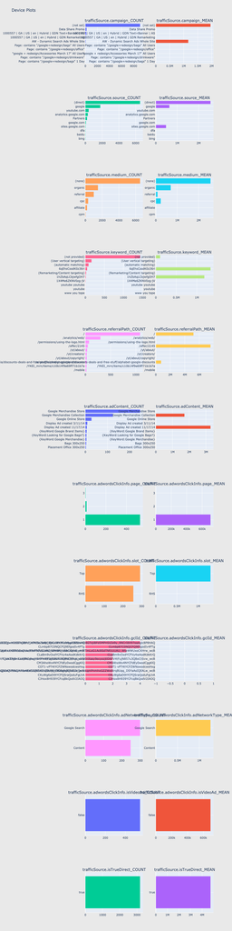

```python
subplot_titles =[]
for c in traffic_source:
    subplot_titles.append(c+'_COUNT')
    subplot_titles.append(c+'_MEAN')

fig = plotly.subplots.make_subplots(rows=len(traffic_source), cols=2,
                                    subplot_titles=subplot_titles)

for i in range(len(traffic_source)):
    fig.append_trace(traffic_source_dict[(i+1,1)], i+1, 1)
    fig.append_trace(traffic_source_dict[(i+1,2)], i+1, 2)
fig['layout'].update(height=4000, width=1000, paper_bgcolor='rgb(233,233,233)', title="Device Plots")

#fig.show(format='svg')
#py.iplot(fig, filename='device-plots')
Image(pio.to_image(fig, format='png'))
```

# trafficSource Observation

Above, we observe that in many cases, there are fair amount of relationships between traffic sources and transactions. For instance, in trafficSource.source column, '(direct)' source shows higer trasaction while the count of the '(direct)' source is fairly large.

In most cases, 10 largest sources in terms of count explain most of total counts. This implies that maximum dimension of PCA for the most traffic source columns will be 10.

```python
for c in traffic_source:
    print(c, 'number of unique:'+ str(train[c].nunique()), 'number of null:' +str(train[c].isnull().sum()/train.shape[0]))
```

```
trafficSource.campaign number of unique:21 number of null:0.0
trafficSource.source number of unique:146 number of null:0.0
trafficSource.medium number of unique:7 number of null:0.0
trafficSource.keyword number of unique:884 number of null:0.5329295116916517
trafficSource.referralPath number of unique:798 number of null:0.757436296572028
trafficSource.adContent number of unique:47 number of null:0.9405231633447261
trafficSource.adwordsClickInfo.page number of unique:4 number of null:0.928733376197083
trafficSource.adwordsClickInfo.slot number of unique:2 number of null:0.928733376197083
trafficSource.adwordsClickInfo.gclId number of unique:9638 number of null:0.9286995363947075
trafficSource.adwordsClickInfo.adNetworkType number of unique:2 number of null:0.928733376197083
trafficSource.adwordsClickInfo.isVideoAd number of unique:1 number of null:0.928733376197083
trafficSource.isTrueDirect number of unique:1 number of null:0.6710094413048627
```

```python
'''
--------------------dimension to use for PCA--------------------

'''


pca_dim_traffic = {'trafficSource.campaign':6,'trafficSource.source': 4, 'trafficSource.medium': 5,
                  'trafficSource.adContent':2,
                  'trafficSource.adwordsClickInfo.page':2, 'trafficSource.adwordsClickInfo.slot':3,
                   'trafficSource.adwordsClickInfo.adNetworkType':3,
                  'trafficSource.adwordsClickInfo.isVideoAd':2, 'trafficSource.isTrueDirect':2
                  }
```

# Geographic Network Information

Here, we explore how Geographic Networks are related to average transactions for each visit. Throughout this observation, we'd like to determine proper number of dimension of geoNetwork columns during Principle Component Analysis (PCA) algorithm.

The second column of the follwing graph chart indicates avaerage trasaction for each category.

```python
geoNetwork = ['geoNetwork.continent', 'geoNetwork.subContinent',
       'geoNetwork.country', 'geoNetwork.region', 'geoNetwork.metro',
       'geoNetwork.city', 'geoNetwork.networkDomain']


i = 1
geoNetwork_dict = {}
for c in geoNetwork:
    cnt_srs = train.groupby(c)['totals.transactionRevenue'].agg(['size', 'mean'])
    cnt_srs.columns = ["count", "mean"]
    cnt_srs = cnt_srs.sort_values(by="count", ascending=False)
    geoNetwork_dict[(i,1)] = horizontal_bar_chart(cnt_srs["count"].head(10), 'rgba(50, 171, 96, 0.6)')
    geoNetwork_dict[(i,2)] = horizontal_bar_chart(cnt_srs["mean"].head(10), 'rgba(50, 171, 96, 0.6)')
    i += 1
```

```python
subplot_titles =[]
for c in geoNetwork:
    subplot_titles.append(c+'_COUNT')
    subplot_titles.append(c+'_MEAN')

fig = plotly.subplots.make_subplots(rows=len(geoNetwork), cols=2,subplot_titles=subplot_titles)
for i in range(len(geoNetwork)):
    fig.append_trace(geoNetwork_dict[(i+1,1)], i+1, 1)
    fig.append_trace(geoNetwork_dict[(i+1,2)], i+1, 2)
fig['layout'].update(height=5000, width=1000, paper_bgcolor='rgb(233,233,233)', title="Device Plots")
py.iplot(fig, filename='device-plots')
```

[figure not shown]

# GeoNetwork Observation

We observe that Geographic Network information provides very meaningful implications for the trasactions. For example, geoNetwork.continent column show that transactions are signficantly higher in Americas in comparison with Europe and Asia.

For other gegraphic network columns, we perform the PCA

```python
'''
--------------------dimension to use for PCA--------------------

'''

pca_dim_geoNetwork = {'geoNetwork.continent': 6,'geoNetwork.subContinent': 10, 'geoNetwork.country':10,
                     'geoNetwork.region':10, 'geoNetwork.metro':10
                     }
```

```python
for c in geoNetwork:
    print(c, 'number of unique:'+ str(train[c].nunique()), 'number of null:' +str(train[c].isnull().sum()/train.shape[0]))
```

```
geoNetwork.continent number of unique:6 number of null:0.0
geoNetwork.subContinent number of unique:23 number of null:0.0
geoNetwork.country number of unique:202 number of null:0.0
geoNetwork.region number of unique:281 number of null:0.0
geoNetwork.metro number of unique:91 number of null:0.0
geoNetwork.city number of unique:523 number of null:0.0
geoNetwork.networkDomain number of unique:9986 number of null:0.0
```

# Device Information

Here, we explore how devices used are related to average transactions for each visit. Throughout this observation, we'd like to determine proper number of dimension of device columns during Principle Component Analysis (PCA) algorithm.

The second column of the follwing graph chart indicates avaerage trasaction for each category.

```python
device = ['device.browser',
       'device.operatingSystem', 'device.isMobile', 'device.deviceCategory']

i = 1
device_dict = {}
for c in device:
    cnt_srs = train.groupby(c)['totals.transactionRevenue'].agg(['size', 'mean'])
    cnt_srs.columns = ["count", "mean"]
    cnt_srs = cnt_srs.sort_values(by="count", ascending=False)
    device_dict[(i,1)] = horizontal_bar_chart(cnt_srs["count"].head(10), 'rgba(50, 171, 96, 0.6)')
    device_dict[(i,2)] = horizontal_bar_chart(cnt_srs["mean"].head(10), 'rgba(50, 171, 96, 0.6)')
    i += 1
```

```python
subplot_titles =[]
for c in device:
    subplot_titles.append(c+'_COUNT')
    subplot_titles.append(c+'_MEAN')

fig = plotly.subplots.make_subplots(rows=len(device), cols=2,subplot_titles=subplot_titles)
for i in range(len(device)):
    fig.append_trace(device_dict[(i+1,1)], i+1, 1)
    fig.append_trace(device_dict[(i+1,2)], i+1, 2)
fig['layout'].update(height=1200, width=1000, paper_bgcolor='rgb(233,233,233)', title="Device Plots")
py.iplot(fig, filename='device-plots')
```

[output not shown]

# Device Observation

We observe that device information provides very meaningful implications for the trasactions. For example, device.Browser column show that transactions are signficantly higher in Chrome in comparison with Internet Expolrer and Safari.

```python
'''
--------------------dimension to use for PCA--------------------

'''

pca_dim_device = {'device.browser':8, 'device.operatingSystem':8,
                 'device.isMobile':2, 'device.deviceCategory':3}
```

```python
for c in device:
    print(c, 'number of unique:'+ str(train[c].nunique()), 'number of null:' +str(train[c].isnull().sum()/train.shape[0]))
```

```
device.browser number of unique:38 number of null:0.0
device.operatingSystem number of unique:18 number of null:0.0
device.isMobile number of unique:2 number of null:0.0
device.deviceCategory number of unique:3 number of null:0.0
```

# Principal Component Analysis

1. we first apply one-hot encoding for categorical columns

2. then, normalize the one-hot encoded columns

3. finally excute the dimension reduction process.

```python
from sklearn.decomposition import PCA, IncrementalPCA
from sklearn.preprocessing import StandardScaler,MinMaxScaler


def one_hot_pca(df,column_name,dummy_na,n_comp = None):
    # return Numpy array
    y = pd.get_dummies(df[column_name], prefix=column_name[:5],dummy_na=dummy_na)
    sc = StandardScaler()
    y = pd.DataFrame(sc.fit_transform(y),columns = y.columns,index=y.index)
    if n_comp:
        pca = PCA(n_components = n_comp)
    else:
        pca = PCA(n_components = 'mle')
    y = pd.DataFrame(pca.fit_transform(y), index=y.index,columns=[column_name + str(i) for i in range(n_comp)])
    return y
```

```python
def one_hot_pca_batch(df,column_name, dummy_na, batch_size,n_comp = None):
    # return Numpy array
    y = pd.get_dummies(df[column_name], prefix=column_name[:5],dummy_na=dummy_na)
    sc = StandardScaler()
    y = pd.DataFrame(sc.fit_transform(y),columns = y.columns,index=y.index)
    if n_comp:
        n_bachtes = batch_size
        inc_pca = IncrementalPCA(n_components = n_comp)
        for x_batch in np.array_split(y,n_bachtes):
            inc_pca.partial_fit(x_batch)
    else:
        pca = PCA(n_components = 'mle')
    y = pd.DataFrame(inc_pca.transform(y), index=y.index,columns=[column_name + str(i) for i in range(n_comp)])
    return y
```

# One_hot encoding

Rememeber that there are some categorical columns in which we would just perform one_hot encoding instead of PCA

To do one_hot encoding

1. we first apply one-hot encoding for categorical columns

2. then, normalize the one-hot encoded columns

```python
def one_hot(df,column_name,dummy_na):
    # return Numpy array
    y = pd.get_dummies(df[column_name], prefix=column_name[:5],dummy_na=dummy_na)
    sc = StandardScaler()
    y = pd.DataFrame(sc.fit_transform(y),columns = y.columns,index=y.index)
    return y
```

# Normalization

For the numerical columns we perform standard scalar normilization,i.e.,

1. subtract mean

2. and divide by standard deviation.

```python
def scale(df,column_name):
    # return Numpy array
    #df[column_name] = df[column_name].astype(float)
    sc = StandardScaler()
    df[column_name] = sc.fit_transform(sc.fit_transform(df[[column_name]]))
```

```python
'''
-----------Perform one_hot encoding, PCA and normalization for device columns------------------
'''


for k,v in pca_dim_device.items():
    y = one_hot_pca(train,k,True,v)
    train = train.drop(k,axis=1)
    train = train.join(y)
```

```python
'''
-----------Perform one_hot encoding, PCA and normalization for geoNetwork columns------------------
'''

for k,v in pca_dim_geoNetwork.items():
    y = one_hot_pca(train,k,True,v)
    train = train.drop(k,axis=1)
    train = train.join(y)
```

```python
'''
-----------Perform one_hot encoding, PCA and normalization for traffic source columns------------------
'''

for k,v in pca_dim_traffic.items():
    y = one_hot_pca(train,k,True,v)
    train = train.drop(k,axis=1)
    train = train.join(y)
```

```python
train = train.drop(['trafficSource.referralPath','trafficSource.keyword',
                    'trafficSource.adwordsClickInfo.gclId',
                   'geoNetwork.city','geoNetwork.networkDomain',
                   'visitStartTime','visitId',
                   'date'],axis=1)
```

```python
'''
-----------Perform one_hot encoding for the channel Grouping columns------------------
'''

to_be_one_hot = ['channelGrouping','date_']

for c in to_be_one_hot:
    y = one_hot(train,c,train[c].isnull().sum() > 1)
    train = train.drop(c,axis=1)
    train = train.join(y)
```

```python
'''
-----------totals columns have numerical values. Change type to float and fill empty values------------------
'''



train['totals.newVisits'] = train['totals.newVisits'].astype(float)
train['totals.newVisits'].fillna(0, inplace=True)
train['totals.timeOnSite'] = train['totals.timeOnSite'].astype(float)
train['totals.timeOnSite'].fillna(train['totals.timeOnSite'].mean(), inplace=True)
train['totals.bounces'] = train['totals.bounces'].astype(float)
train['totals.bounces'].fillna(0, inplace=True)
train['totals.hits'] = train['totals.hits'].astype(float)
train['totals.pageviews'] = train['totals.pageviews'].astype(float)
train['totals.pageviews'].fillna(0, inplace=True)
train = train.drop(['totals.sessionQualityDim'],axis=1)
```

```python
'''
-----------------------Normalize numerical values------------------------------
'''

to_be_scaled = ['visitNumber','totals.hits','totals.pageviews','totals.timeOnSite',
                'totals.newVisits',
                'totals.transactions',
                'totals.transactionRevenue','totals.totalTransactionRevenue','totals.bounces']
for c in to_be_scaled:
    scale(train,c)
```

# Summary after feature engineering (Normalization, PCA, One_hot econding etc)

```python
train.head()
```

|  | fullVisitorId | visitNumber | totals.hits | totals.pageviews | totals.bounces | totals.newVisits | totals.timeOnSite | totals.transactions | totals.transactionRevenue | totals.totalTransactionRevenue | device.browser0 | device.browser1 | device.browser2 | device.browser3 | device.browser4 | device.browser5 | device.browser6 | device.browser7 | device.operatingSystem0 | device.operatingSystem1 | device.operatingSystem2 | device.operatingSystem3 | device.operatingSystem4 | device.operatingSystem5 | device.operatingSystem6 | device.operatingSystem7 | device.isMobile0 | device.isMobile1 | device.deviceCategory0 | … |
| --- | --- | --- | --- | --- | --- | --- | --- | --- | --- | --- | --- | --- | --- | --- | --- | --- | --- | --- | --- | --- | --- | --- | --- | --- | --- | --- | --- | --- | --- | --- |
| 0 | 3162355547410993243 | -0.142970 | -0.386621 | -0.421954 | 0.935653 | 0.569154 | 8.692996e-18 | -0.108285 | -0.031169 | -0.0231 | 1.819898 | -2.927731 | 2.141954 | 0.683791 | 0.193770 | -0.217127 | -0.095390 | 0.391613 | 1.680658 | -0.077053 | -0.188761 | -0.155850 | -0.037446 | -0.029716 | -0.011847 | -0.005134 | -1.109615 | 9.210633e-27 | -1.073211 | … |
| 1 | 8934116514970143966 | 0.454193 | -0.268495 | -0.258201 | -1.068773 | -1.756994 | -7.459256e-01 | -0.108285 | -0.031169 | -0.0231 | -0.876392 | 0.056055 | 0.011706 | 0.002903 | -0.000656 | -0.000775 | -0.000077 | 0.002348 | -0.336498 | 0.064134 | 0.282601 | 2.622491 | 5.086982 | -0.583103 | -0.188883 | -0.080958 | -1.109615 | -9.837069e-33 | -1.073211 | … |
| 2 | 7992466427990357681 | -0.142970 | -0.268495 | -0.258201 | -1.068773 | 0.569154 | -7.160812e-01 | -0.108285 | -0.031169 | -0.0231 | -0.876392 | 0.056055 | 0.011706 | 0.002903 | -0.000656 | -0.000775 | -0.000077 | 0.002348 | -0.911337 | 1.732024 | -0.904754 | -0.313365 | -0.071728 | -0.054057 | -0.021334 | -0.009240 | 1.802426 | -5.875874e-31 | 1.865423 | … |
| 3 | 9075655783635761930 | -0.142970 | -0.268495 | -0.258201 | -1.068773 | 0.569154 | -8.265056e-01 | -0.108285 | -0.031169 | -0.0231 | -0.876392 | 0.056055 | 0.011706 | 0.002903 | -0.000656 | -0.000775 | -0.000077 | 0.002348 | 1.680658 | -0.077053 | -0.188761 | -0.155850 | -0.037446 | -0.029716 | -0.011847 | -0.005134 | -1.109615 | -8.708557e-33 | -1.073211 | … |
| 4 | 6960673291025684308 | -0.142970 | -0.268495 | -0.258201 | -1.068773 | 0.569154 | -6.742990e-01 | -0.108285 | -0.031169 | -0.0231 | -0.876392 | 0.056055 | 0.011706 | 0.002903 | -0.000656 | -0.000775 | -0.000077 | 0.002348 | 1.680658 | -0.077053 | -0.188761 | -0.155850 | -0.037446 | -0.029716 | -0.011847 | -0.005134 | -1.109615 | -8.708557e-33 | -1.073211 | … |

```python
train.info(verbose=True,max_cols=5000)
```

```
<class 'pandas.core.frame.DataFrame'>
Int64Index: 474124 entries, 0 to 748306
Data columns (total 120 columns):
 #   Column                                         Non-Null Count   Dtype
---  ------                                         --------------   -----
 0   fullVisitorId                                  474124 non-null  object
 1   visitNumber                                    474124 non-null  float64
 2   totals.hits                                    474124 non-null  float64
 3   totals.pageviews                               474124 non-null  float64
 4   totals.bounces                                 474124 non-null  float64
 5   totals.newVisits                               474124 non-null  float64
 6   totals.timeOnSite                              474124 non-null  float64
 7   totals.transactions                            474124 non-null  float64
 8   totals.transactionRevenue                      474124 non-null  float64
 9   totals.totalTransactionRevenue                 474124 non-null  float64
```

[output cut: 112 more lines]

# Rearrange Data with respect to full visitor ID

Recall that our goal is to predict each consumers' future transactions. Thus, one of the most important part of is to rearrange our data in terms of full visitor ID.

Here, we make Python dictionary where keys are full visitor IDs and values are lists of their transactions log

```python
train_dict = train.groupby('fullVisitorId')[train.columns[1:]].apply(lambda g: g.values.tolist()).to_dict()
```

# Make target varialbe for each visitor ID

for each visitor ID, the target varialbe is the amount of transactions during the period December 2017 to January 2018

```python
target = df.loc[(20171201 <= df['date'])  &(df['date'] < 20180201)]
target_dict = target.groupby('fullVisitorId')['totals.transactionRevenue'].apply(lambda g: g.values.sum()).to_dict()
```

# Preprocess for the efficient training

Before we perform actual training using LSTM, we preprocess data so that we utilize mini-batch size training. Using mini batch size siginificantly improves the time effieicny of the training.

To do so, we group visit log in terms of the number of the visits. Due to the technical constraint, we have to feed training sets which have the same number of time steps for each training session.

```python
import math
from collections import defaultdict
train_dict2 = defaultdict(list)
target_dict_log = defaultdict(list)
for k,v in train_dict.items():
    temp = np.asarray(v)
    train_dict2[temp.shape[0]].append(temp)
    #target_dict_log[temp.shape[0]].append([target_dict[k]] if k in target_dict else [0.0])
    target_dict_log[temp.shape[0]].append([math.log(1+target_dict[k])] if k in target_dict else [0.0] )
```

```python
'''
--------------- Change the Python array to Numpy array to feed these to Tensorflow training -----------------

'''

for k,v in train_dict2.items():
    train_dict2[k] = np.asarray(v)
for k,v in target_dict_log.items():
    target_dict_log[k] = np.asarray(v)
```

# Build the LSTM model using Keras API

BWe use stacked LSTM model. For the optimizer, we use ADAM for fast optimization

```python
from keras.models import Sequential
from keras.layers import LSTM, Dense, TimeDistributed
from keras.utils import to_categorical
from keras.preprocessing import sequence
from keras import optimizers


model = Sequential()

model.add(LSTM(250, return_sequences=True, input_shape=(None, 119)))
model.add(LSTM(100, return_sequences=True))
model.add(LSTM(20, return_sequences=False))
model.add(Dense(1, activation='linear'))
#model.add(TimeDistributed(Dense(1)))
print(model.summary(100))

model.compile(loss='mse',
              optimizer='adam')
```

```
Model: "sequential"
____________________________________________________________________________________________________
Layer (type)                                 Output Shape                            Param #
====================================================================================================
lstm (LSTM)                                  (None, None, 250)                       370000
____________________________________________________________________________________________________
lstm_1 (LSTM)                                (None, None, 100)                       140400
____________________________________________________________________________________________________
lstm_2 (LSTM)                                (None, 20)                              9680
____________________________________________________________________________________________________
dense (Dense)                                (None, 1)                               21
====================================================================================================
Total params: 520,101
Trainable params: 520,101
Non-trainable params: 0
____________________________________________________________________________________________________
None
```

# Training

Feed preprocessed data to our LSTM model

```python
for j in range(5):
    for i in train_dict2:
        model.fit(train_dict2[i],target_dict_log[i], epochs=1,
                  batch_size=max(256//(2**i),16),verbose=1)
```

# Save the trained model

The saved model will be applied to test set later.

```python
model.save('google_revenue_range_1to6_5times_LSTM.h5')
```